# Post 01 - Reactivity in Shiny Apps

Donggyun Kim

10/30/2017

# 1. Introduction

In recent classes and labs, we learned about what is a Shiny app and how to build it.  
In order to build a Shiny app, we use almost same coding style we have been used  
in Rmd or R script files. However, Shiny apps own a special structure that seems  
somewhat different from Rmd or R script files although it is built by an R script  
file. Moreover, Shiny apps possess a nice trait, **reactivity**, that reduces the  
effort of rewriting code or changing initial value(*input*) to see different results  
(*output*). In other words, this trait makes it possible to compare each result of  
each initial value to others simultaneously, which also means it is interactive.  
In this post, I want to talk about what **reactivity** is and how it works in Shiny apps.

# 2. Structure of Shiny Apps

To talk about **reactivity**, we first get familiar with the structure of Shiny apps.

[figure not shown]

When you create new Shiny app file in RStudio, you will see a basic example as a guideline  
for building Shiny apps.

```r
library(shiny)

# Define UI for application that draws a histogram
ui <- fluidPage(

   # Application title
   titlePanel("Old Faithful Geyser Data"),

   # Sidebar with a slider input for number of bins
   sidebarLayout(
      sidebarPanel(
         sliderInput("bins",
                     "Number of bins:",
                     min = 1,
                     max = 50,
                     value = 30)
      ),

      # Show a plot of the generated distribution
      mainPanel(
         plotOutput("distPlot")
      )
   )
)

# Define server logic required to draw a histogram
server <- function(input, output) {

   output$distPlot <- renderPlot({
      # generate bins based on input$bins from ui.R
      x    <- faithful[, 2]
      bins <- seq(min(x), max(x), length.out = input$bins + 1)

      # draw the histogram with the specified number of bins
      hist(x, breaks = bins, col = 'darkgray', border = 'white')
   })
}

# Run the application
shinyApp(ui = ui, server = server)
```

This template shows that the app consists of **three components**.

`ui`: User Interface object that manages the appearance of the app  
`server`: Function that contains instructions for computer to build the app  
`shinyApp`: Function that executes the app

When you in RStudio, you will see how the app looks as the below image.

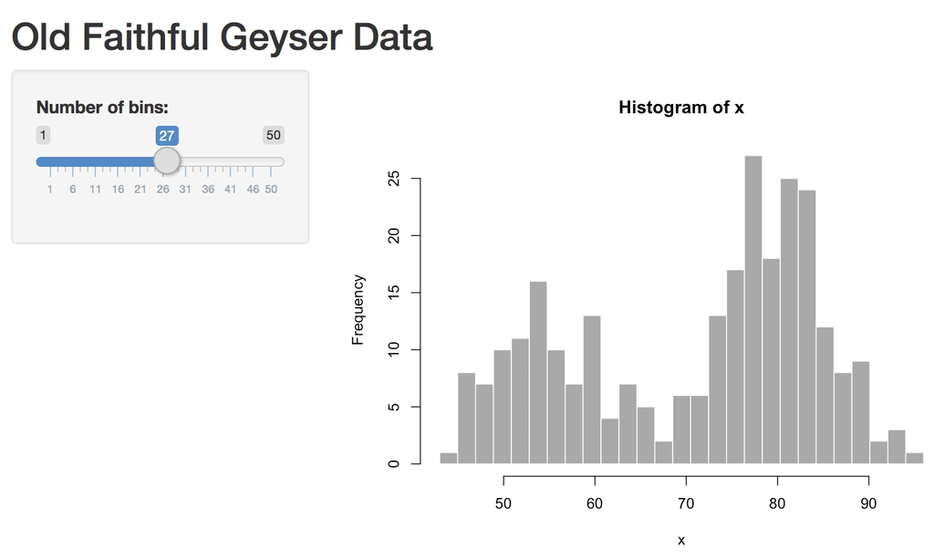

Before moving on **reactivity**, let me talk briefly about two components:  
`ui` and `server`.

1. `ui` **User Interface**

```r
ui <- fluidPage(

   # Application title
   titlePanel("Old Faithful Geyser Data"),

   # Sidebar with a slider input for number of bins
   sidebarLayout(
      sidebarPanel(
         sliderInput("bins",
                     "Number of bins:",
                     min = 1,
                     max = 50,
                     value = 30)
      ),

      # Show a plot of the generated distribution
      mainPanel(
         plotOutput("distPlot")
      )
   )
)
```

This is a code structure of `ui`. It contains `titlePanel()` and `slidebarLayout()`.

- `titlePanel()` represents the title of the app. In this example,

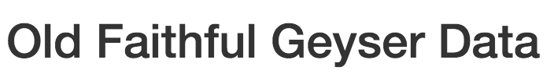

- `slidebarLayout()` contains two functions, `sidebarPanel()` and `mainPanel()`.
  - `sidebarPanel()` represents the initial value(*input*) of the app and takes the input  
    from users. In this example,

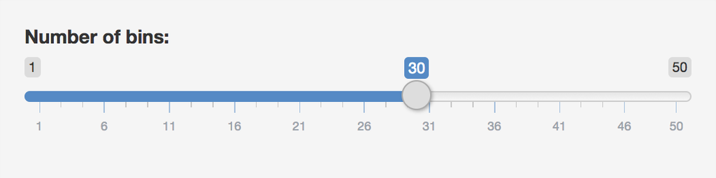

  - `mainPanel()` represents the result(*output*) of the app. In this example,

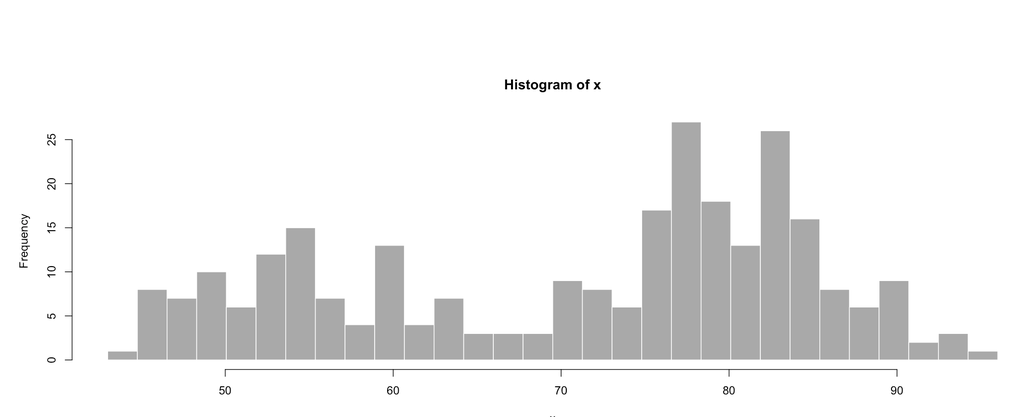

In the following sections, I will focus on `slidebarLayout()` to talk about **reactivity**.

2. `server` **Function**

```r
server <- function(input, output) {

   output$distPlot <- renderPlot({
      # generate bins based on input$bins from ui.R
      x    <- faithful[, 2]
      bins <- seq(min(x), max(x), length.out = input$bins + 1)

      # draw the histogram with the specified number of bins
      hist(x, breaks = bins, col = 'darkgray', border = 'white')
   })
}
```

Server function contains two *arguments*: `input` and `output`. This is because  
`server` function plays a central role in **reactivity**. When users set initial  
or input value through `ui`, `server` function takes input value from `ui`,  
executes code with input value, and sends output to `ui` so that users can see  
the result.

You may notice that I repeated two words, *input* and *output*. You will see the  
reason why I did so.

# 3. What is reactivity?

It is easy to understand **reactivity** when you think about how functions work in R.

```r
#create reactivity function
reactivity <- function(input) {
  output <- 2*input
  output
}

#users set initial value(input) 2
input <- 2

#reactivity function takes input value 2,
#execute code with the input,
#and print the result(output)

reactivity(input)
```

```
## [1] 4
```

The *output* of `reactivity` function depends on only *input* unless the function is  
redefined. That is, *input* **interacts** with *output* through the `reactivity` function.

```r
#set different input
input <- 3
reactivity(input)
```

```
## [1] 6
```

```r
#set another different input
input <- 4
reactivity(input)
```

```
## [1] 8
```

Every time you set different input, `reactivity` function produces different output.

# 4. How does reactivity work in Shiny apps?

```r
# Sidebar with a slider input for number of bins
   sidebarLayout(
      sidebarPanel(
         sliderInput("bins",              #inputId = "bins"
                     "Number of bins:",
                     min = 1,
                     max = 50,
                     value = 30)
      )
```

In `ui` part, `sliderInput()` is in charge of taking input from users. It has `inputId`  
argument, which corresponds to “bins” in this example. `server` function interacts this  
`inputId` argument using “**input$**” operator.

```r
output$distPlot <- renderPlot({
      # generate bins based on input$bins from ui.R
      x    <- faithful[, 2]

      # input$ operator used to manage the length of bins
      bins <- seq(min(x), max(x), length.out = input$bins + 1)

      # draw the histogram with the specified number of bins
      hist(x, breaks = bins, col = 'darkgray', border = 'white')
   })
```

That is, when users set the input value, `server` function executes code with input  
value and produce the result. The result also will be connected with specified  
`outputId`.

```r
output$distPlot <- renderPlot({     #outputId = distPlot

  ...

  })
```

In this example, the outputId is “**distPlot**”.

```r
ui <- fluidPage(

  ...

   # Show a plot of the generated distribution
      mainPanel(
         plotOutput("distPlot")
      )
)
```

`ui` shows the result on the mainPanel calling `plotOutput`function with  
“**distPlot**” argument.  
If the user sets input value as 6,

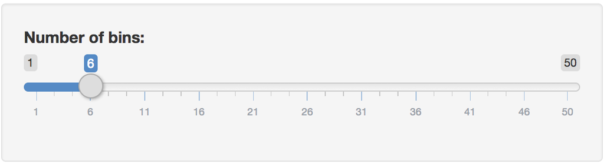

the histogram shows the result with 6 bins.

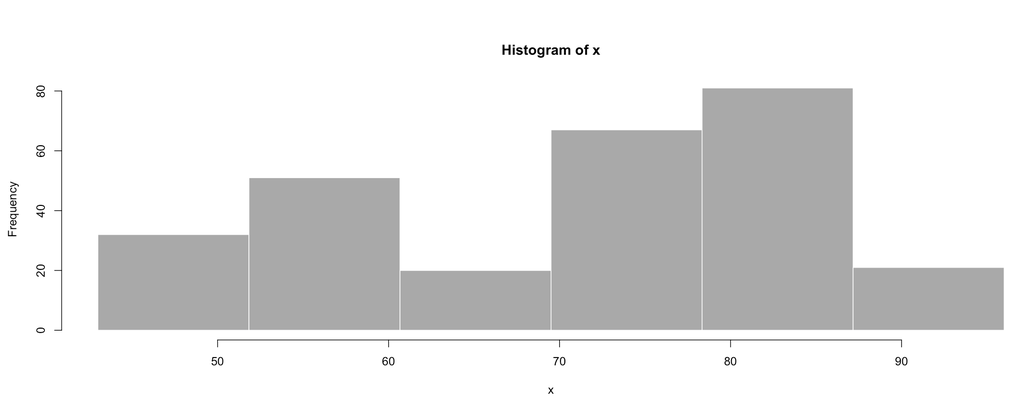

If the user sets input value as 15,

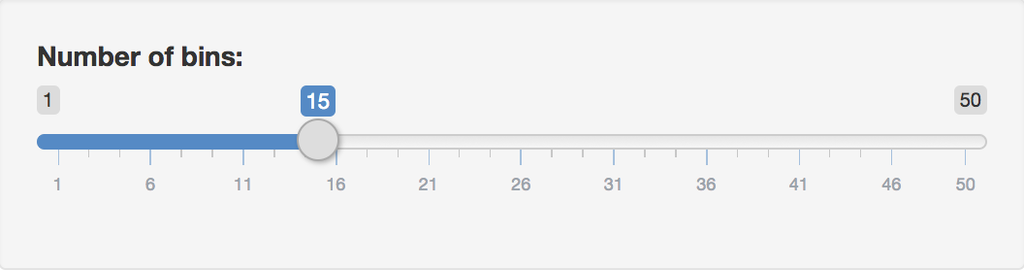

the histogram shows the result with 15 bins.

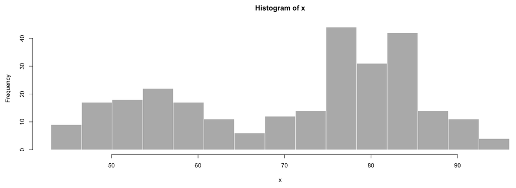

# 5. Conclusion

**Reactivity** in Shiny apps happens in a condition where *input* set by user  
**interacts** simultaneously with *output*. Since both *input* and *output* are  
displayed on `ui` as described above sections, users can easily check what is  
happening on the app whenever they change the input value.

Although it seems quite simple and basic concept, I personally consider **reactivity**  
as a main building block of Shiny apps. Also, I believe that if we fully understand  
the concept of **reactivity**, it would be a great help for us to study more about  
Shiny apps.

# 6. References

[Reactivity - An overview](https://shiny.rstudio.com/articles/reactivity-overview.html) by RStudio  
[How to understand reactivity in R](https://shiny.rstudio.com/articles/understanding-reactivity.html) by Garret Grolemund  
[Shiny Tutorial - Structure of a Shiny App](https://bookdown.org/weicheng/shinyTutorial/structure-of-a-shiny-app.html) by Weicheng Zhu  
[Shiny Tutorial - UI](https://bookdown.org/weicheng/shinyTutorial/ui.html) by Weicheng Zhu  
[Shiny Tutorial - Server](https://bookdown.org/weicheng/shinyTutorial/server.html) by Weicheng Zhu  
[R Shiny app tutorial # 1 - How to make shiny apps - An introduction to Shiny](https://www.youtube.com/watch?v=_0ORRJqctHE&t=4s) by Abhinav Agrawal  
[Rstudio Tutorial: developing a web application with Shiny package](https://www.youtube.com/watch?v=Gyrfsrd4zK0) by Ehsan Jahanpour  
[Tutorial: creating webapps with R using Shiny](http://stcorp.nl/R_course/tutorial_shiny.html) by Paul Hiemstra  
[Data Science Lab: R Shiny Application with Reactivity and Buttons](https://www.youtube.com/watch?v=63KnV4XWsR0) by John Muschelli  
[R Shiny app tutorial # 7 - how to plot using renderPlot() in shiny - Example of a reactive histogram](https://www.youtube.com/watch?v=z5bUzdIbIyg) by Abhinav Agrawal  
[Building Shiny Apps](http://cfss.uchicago.edu/shiny001_abc.html)  
[Shiny Cheat Sheet](http://shiny.rstudio.com/images/shiny-cheatsheet.pdf) by RStudio